# Describing Distributions ▶ Categorical Data

Updated: Monday, February 04, 2019 @ 07:57:58 PM

[figure not shown]

"…the object of statistical methods is the reduction of data. A quantity of data, which usually by its mere bulk is incapable of entering the mind, is to be replaced by relatively few quantities which shall adequately represent the whole, or…shall contain as much as possible, ideally the whole, of the relevant information contained in the original data." ~ R.A. Fisher, 1921

## How We Describe Distributions

**Categorical Variables**

- frequency / relative frequency

*Summaries based on counting how many times categories occur.*

**Quantitative Variables**

- shape
- center
- spread
- outliers

*Shape, center, and spread characterize the pattern of numerical observations. Outliers are deviations from the pattern.*

## Exploring Categorical Data

- frequency table
- relative frequency table
- cumulative frequency table
- cumulative relative frequency table
- contingency table
- [bar chart / barplot](https://ggplot2.tidyverse.org/reference/geom_bar.html)
- pie chart

“There is no data that can be displayed in a pie chart that cannot be displayed better in some other type of chart.” (some attribute this quote to John Tukey, and while that fact cannot be verified, it is generally a true statement)

## Frequency Tables

In the early 1970s, UC Berkeley was concerned about possible sex discrimination in grad school admissions. The berkeley.csv dataset contains fall 1973 data for the six largest departments.

```r
summary(berkdata)
```

```
     sex       department      status
 female:1835   A:933      accepted:1755
 male  :2691   B:585      rejected:2771
               C:918
               D:792
               E:584
               F:714
```

For space, I hid the `read.csv()` code used to import the data and name it `berkdata` using echo=FALSE in the R code chunk.

## Using `table()` and `prop.table()`

```r
table(berkdata$sex)
```

```
female   male
  1835   2691
```

```r
prop.table(table(berkdata$sex))
```

```
   female      male
0.4054353 0.5945647
```

What class of object do `table()` and `prop.table()` produce?

## A `table()` Stored as an Object

```r
statusTab <- table(berkdata$status)
prop.table(statusTab)
```

```
 accepted  rejected
0.3877596 0.6122404
```

```r
round(prop.table(statusTab), 4)
```

```
accepted rejected
  0.3878   0.6122
```

What is the result if you use `as.data.frame()` on statusTab?

Why might you want to convert your summary's object type?

## Contingency (Two-Way) Tables

```r
sexbystatusTab <- table(berkdata$sex, berkdata$status)
print(sexbystatusTab)
```

```
         accepted rejected
  female      557     1278
  male       1198     1493
```

```r
addmargins(sexbystatusTab)
```

```
         accepted rejected  Sum
  female      557     1278 1835
  male       1198     1493 2691
  Sum        1755     2771 4526
```

## Contingency Table as `tidy` Data

```r
as.data.frame(sexbystatusTab)
```

```
    Var1     Var2 Freq
1 female accepted  557
2   male accepted 1198
3 female rejected 1278
4   male rejected 1493
```

This verion of a summary table would be easier to plot with a package like `ggplot2`. Consider the purpose of the summary. Will it be the input for another process?

## Row Proportions

Proportions are calculated by treating each row as a separate frequency table. The rows (not columns) sum to one or 100%.

```r
prop.table(sexbystatusTab, 1)
```

```
          accepted  rejected
  female 0.3035422 0.6964578
  male   0.4451877 0.5548123
```

```r
rowSums(prop.table(sexbystatusTab, 1))
```

```
female   male
     1      1
```

## Column Proportions

Proportions are calculated by treating each column as a table. The columns (not rows) sum to one or 100%.

```r
prop.table(sexbystatusTab, 2)
```

```
          accepted  rejected
  female 0.3173789 0.4612053
  male   0.6826211 0.5387947
```

```r
colSums(prop.table(sexbystatusTab, 2))
```

```
accepted rejected
       1        1
```

## Using `dplyr` to Make "Tables"

The `table()` function produces a named vector or matrix. The method using the `dplyr` package produces a `tibble`.

```r
library(dplyr)
berkdata %>% count(sex)
```

```
# A tibble: 2 x 2
  sex        n
  <fct>  <int>
1 female  1835
2 male    2691
```

Some functions such as `chisq.test()` expect vector or matrix input. Again, consider the reason for making the table.

## Cumulative Frequency Tables

```r
berkdata %>%
  count(department) %>%
  arrange(desc(n)) %>%
  mutate(prop      = prop.table(n),
         cum_count = cumsum(n),
         cum_prop  = cumsum(prop))
```

```
# A tibble: 6 x 5
  department     n  prop cum_count cum_prop
  <fct>      <int> <dbl>     <int>    <dbl>
1 A            933 0.206       933    0.206
2 C            918 0.203      1851    0.409
3 D            792 0.175      2643    0.584
4 F            714 0.158      3357    0.742
5 B            585 0.129      3942    0.871
6 E            584 0.129      4526    1
```

## Using `dplyr` for Contingency Tables

When we use `dplyr` to summarize two variables, we still get all combinations with non-zero counts, but arranged in a `tibble`.

```r
berkdata %>%
  count(sex, status)
```

```
# A tibble: 4 x 3
  sex    status       n
  <fct>  <fct>    <int>
1 female accepted   557
2 female rejected  1278
3 male   accepted  1198
4 male   rejected  1493
```

If a combination has no cases (n = 0), it will not be included in the `tibble`, which may be a problem.

## Rearranging the "Table"

The `tidyr` package has functions like `gather()` and `spread()` to help manipulate `tibble` arrangement.

```r
library(tidyverse)
berkdata %>%
  count(sex, status) %>%
  spread(status, n)
```

```
# A tibble: 2 x 3
  sex    accepted rejected
  <fct>     <int>    <int>
1 female      557     1278
2 male       1198     1493
```

This format could help with data visualization, but is it `tidy`?

## What is "grammar of graphics"?

- R's `ggplot2` is a system for creating graphics, based on the concepts introduced in the book The Grammar of Graphics (2005) — metastructure and connected visualizations
- `aesthetics` (like x, y, color, size, fill) code data or variables from a dataset onto the plot (*what* you want to plot)
- graphical elements displayed in a plot (like points, lines, or bars) are `geometries` (*how* you want to plot)
- you can include multiple geometries on your plot, using the same or different `aesthetics` for each
- facets allow us to visualize the same graphical elements for important groups or subsets of data

## Barplots using `ggplot2`

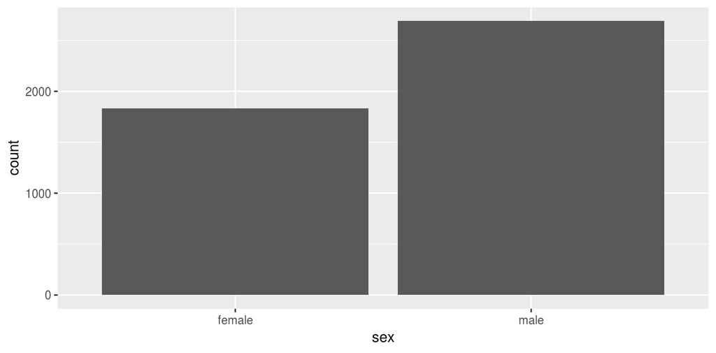

```r
library(ggplot2)
ggplot(berkdata, aes(x = sex)) +
  geom_bar()
```

## Proportions Instead of Counts

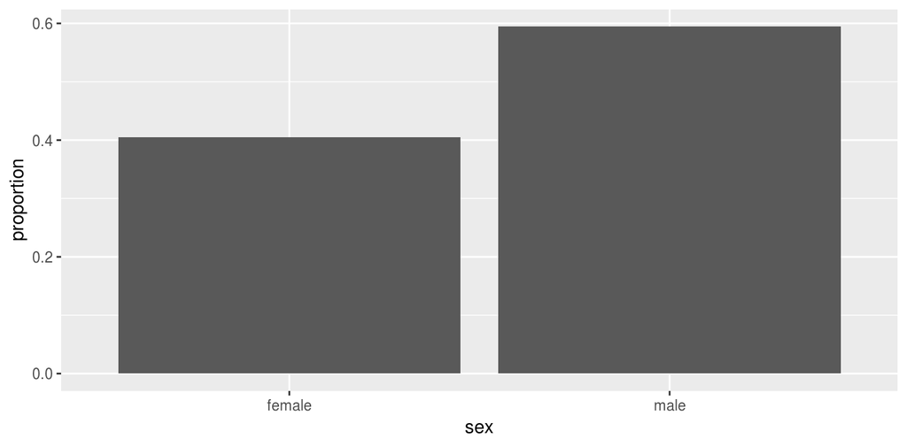

```r
library(ggplot2)
ggplot(berkdata, aes(x = sex)) +
  geom_bar(aes(y=..count../sum(..count..))) + labs(y = "proportion")
```

## Improve the Presentation

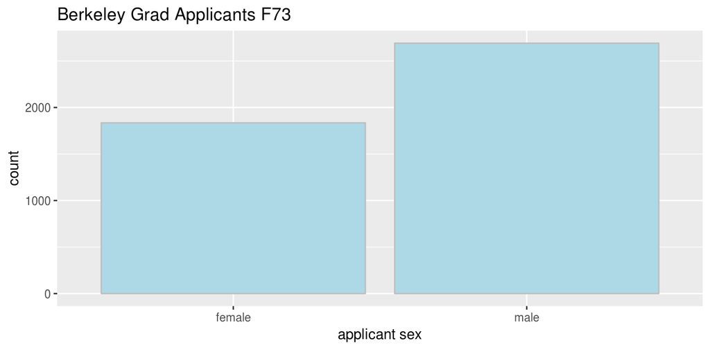

```r
ggplot(berkdata, aes(x = sex)) +
  geom_bar(fill = "lightblue", color = "gray") +
  labs(title = "Berkeley Grad Applicants F73", x = "applicant sex")
```

## Barplots for Two Variables

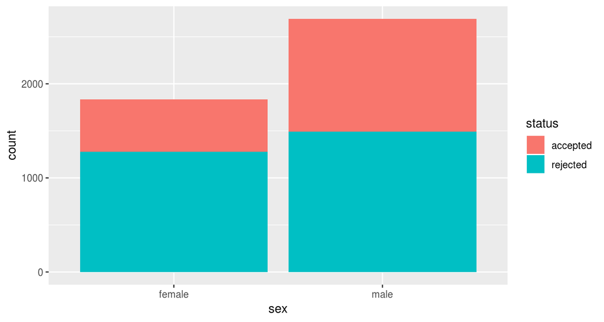

```r
ggplot(berkdata, aes(x = sex, fill = status)) +
  geom_bar()
```

## Bars Side-by-Side vs. Stacked

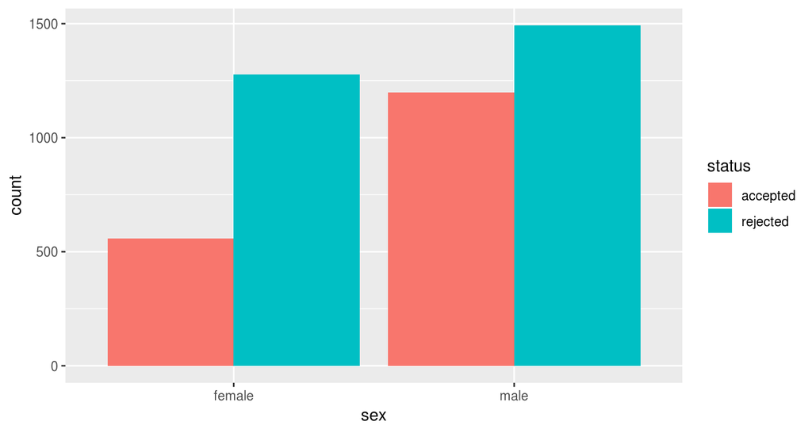

```r
ggplot(berkdata, aes(x = sex, fill = status)) +
  geom_bar(position = "dodge")
```

## Proportions vs. Counts

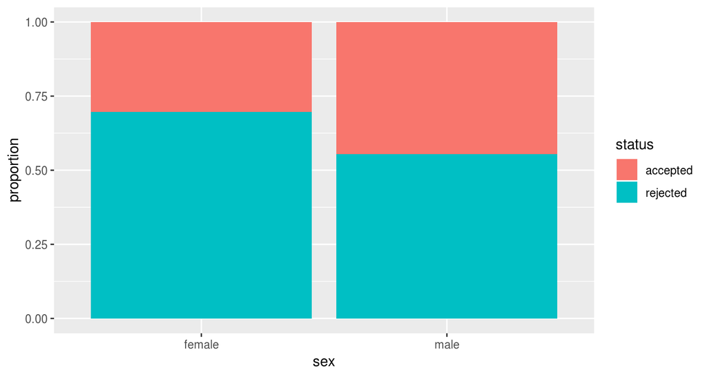

```r
ggplot(berkdata, aes(x = sex, fill = status)) +
  geom_bar(position = "fill") + labs(y = "proportion")
```

## Barplots from Summarized Data

We can still make a barplot if we have summarized vs. raw data.

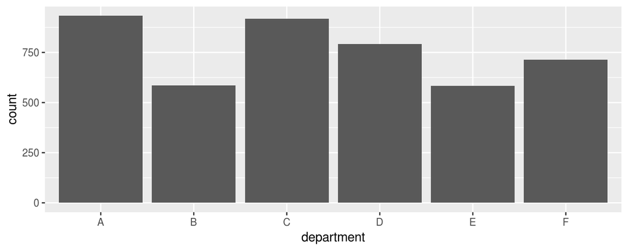

```r
dept_tab <- berkdata %>% count(department)
ggplot(dept_tab, aes(x = department, y = n)) +
  geom_bar(stat = "identity") + labs(y = "count")
```

## Barplots Without a Data Frame

We also can create a barplot from vectors not in a data frame.

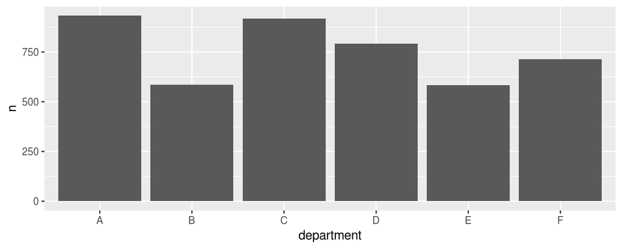

```r
department <- factor(c("A", "B", "C", "D", "E", "F"))
n <- c(933, 585, 918, 792, 584, 714)
ggplot(NULL, aes(x = department, y = n)) + geom_bar(stat = "identity")
```

## More About Color

The online *Cookbook for R* shows some color options and built-in color palettes for plots. You can use colors by name (if it has one that R recognizes, use `colors()` function to see a list), hex code, or rgb value (e.g., [HTML Color Codes](https://htmlcolorcodes.com/color-names/) or [ColorHexa](https://www.colorhexa.com/)).

- *color* typically refers to points, lines, outlines
- *fill* typically refers to some internal shading

```r
ggplot(berkdata, aes(x = sex, fill = status)) +
  geom_bar(color = "darkgray") +
  scale_fill_manual(values = c("palegreen", "turquoise")) +
  labs(title = "Berkeley Grad Applicants, Fall 1973",
       subtitle = "Six Largest Department Applicant Pools",
       caption = "source dataset = berkeley.csv",
       x = "sex of applicant", y = "number of applicants")
```

[figure not shown]

## Three Variables? Use Faceting

Faceting creates multiple "panes" in a plot according to some chosen grouping variable. Use `facet_grid()` or `facet_wrap()` to achieve different configurations.

```r
ggplot(berkdata, aes(x = sex, fill = status)) +
  geom_bar(color = "darkgray") +
  facet_grid(. ~ department) +
  scale_fill_manual(values = c("palegreen", "turquoise")) +
  labs(title = "Berkeley Grad Applicants, Fall 1973",
       subtitle = "Data from Six Largest Department Applicant Pools",
       caption = "source dataset = berkeley.csv",
       x = "sex of applicant",
       y = "number of applicants")
```

Here the six plots are configured into a 1 x 6 facet grid. What happens if you use `facet_grid(department ~ .)` instead?

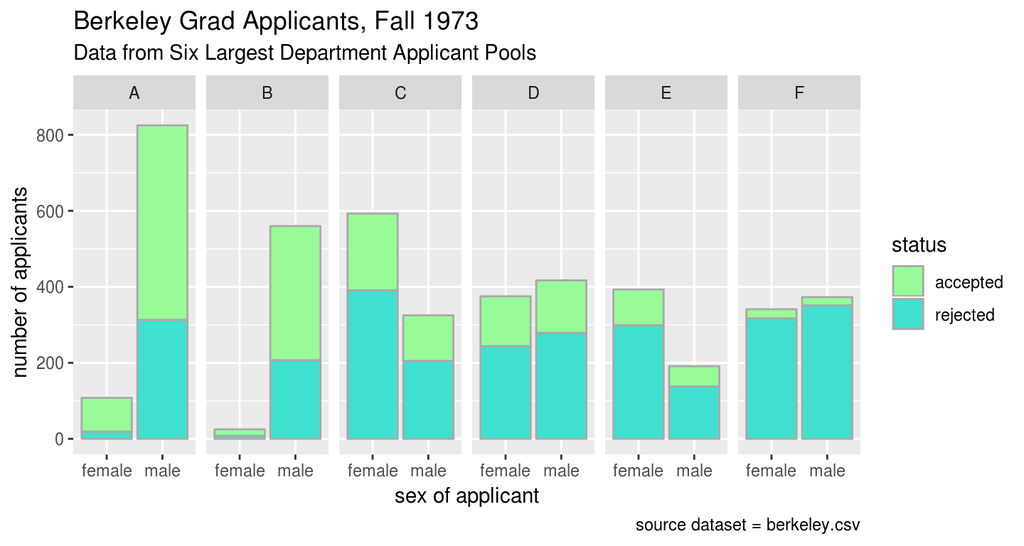

## Use `facet.wrap()` vs. `facet.grid()`

Plots wrapped into rows using `facet_wrap(~ department)`. The wrap tries to optimize for a rectangular arrangement.

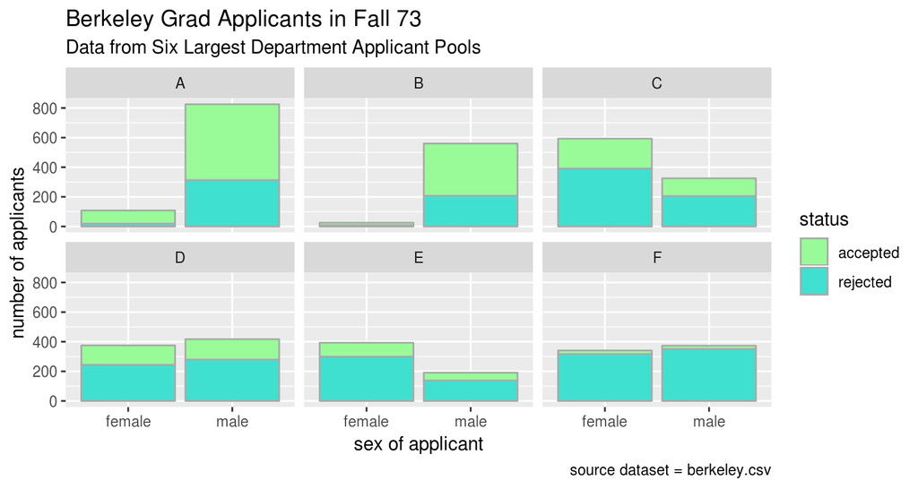

## Conclusions

- Do the overall rejection rates for male and female applicants suggest bias in admissions?
- What does faceting the data by department show with regard to rejection of applicants?
- Are there any other summaries / plots you would like to see? Can you create them?
- Do you prefer tables or barplots for exploring the data? Why?

The Berkeley bias dataset is an example of Simpson's Paradox.

Bickel, P. J., Hammel, E. A., & O’Connell, J. W. (1975). Sex bias in graduate admissions: Data from Berkeley. *Science*, 187(4175), 398–404. http://doi.org/10.1126/science.187.4175.398↩